# assignment 2

david badajkov

1-3-2022

## Assignment 2

### Theoretical Part

We have a the random vector T (X,Y) which has uniform distribution over the set M: M = {(X,Y) R², 0<x<y<1}

We know that over R²; 1 = fx,y(x,y)dxdy and we have fx,y(x,y) = C * 1|0<x<y<1 and therefore; 1 = C * 1/2 C = 2

For (x,y) R², fx,y(x,y) = 2 * 1|0<x<y<1

#### Indepence

From the definition of the random vector it seems that X and Y are dependent because M is defined such that a x value depends on a y value and the other way around. If X and Y are independent, then the following equation needs to hold –> fxy = fx*fy

fx(x) = fxy(x,y)dy fx(x) = 2 * 1|0<x<y<1 dy fx(x) = 2 dy fx(x) = 2 * (1-x) 1|0<x<1

fy(y) = 2 * 1|0<x<y dx fy(y) = 2 dx fy(y) = 2y 1|0<y<1

So for x,y ]0,1[

fy(y)*fx(x) = 2y(1-x)*2 this is not equal to fx,y(x,y)

Therefore, we say that X and Y are not independent.

### Practical

#### simulate a two dimensional random sample from the joint distribution given by the two-dimensional density function

```r
library(ggplot2)

set.seed(11)
n = 5000


x <- runif(n, min = 0, max = 1)
y <- runif(n, min = 0, max = 1)

df = as.data.frame(cbind(x,y))
statement = df$y>df$x
new_df = df[statement,]
```

#### Visualize the result of the data simulation

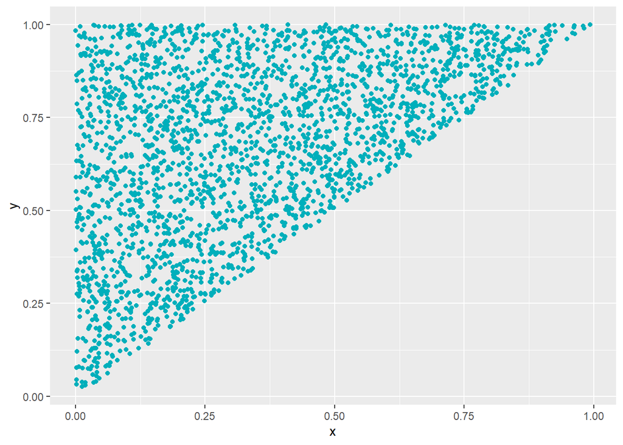

```r
ggplot(new_df, aes(x=x, y=y) ) +
  geom_point(color = "#00AFBB")
```

#### visually verify independence/dependence of some given (two) random variables

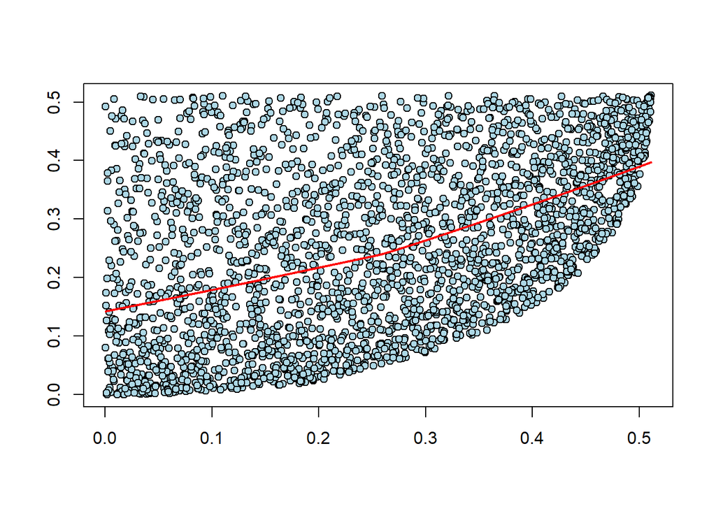

```r
qx <- NULL
qy <- NULL

for (i in 1:n){
  qx <- c(qx, which(sort(new_df$x) == new_df$x[i]))
  qy <- c(qy, which(sort(new_df$y) == new_df$y[i]))
}

qx <- qx / n
qy <- qy / n

plot(qy ~ qx, pch = 21, bg = "lightblue", xlab = "", ylab = "")
lines(lowess(qy ~ qx, f = 1), col = "red", lwd = 2)
```

#### Use some proper graphical tools to verify that the simulated random sample indeed follows the given joint distribution.

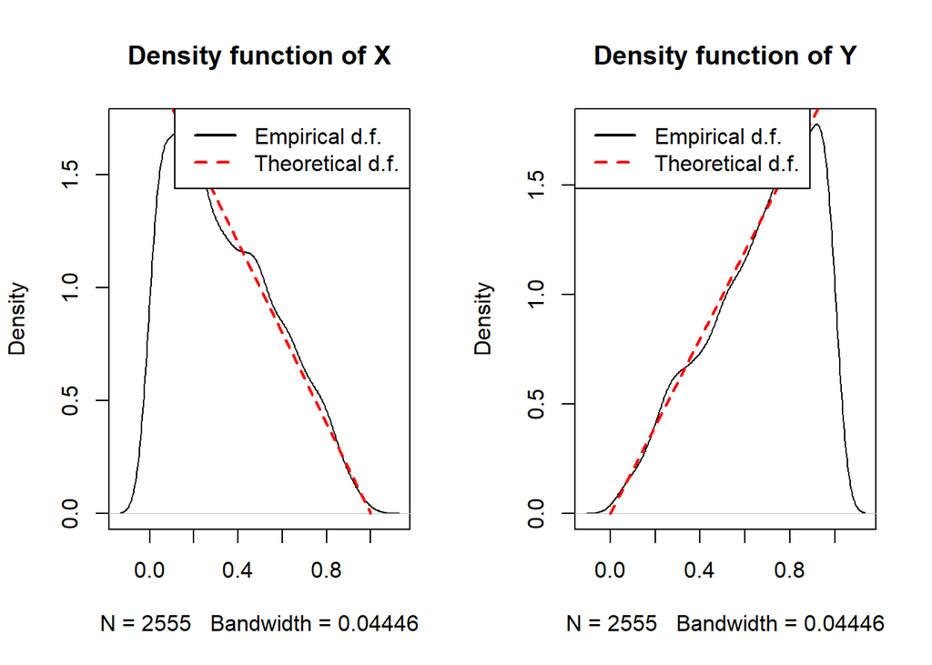

```r
par(mfrow=c(1,2))

xSeq <- seq(0,1, length = length(new_df$x))

plot(density(new_df$x), main = "Density function of X")
lines(2-xSeq*2 ~ xSeq, col = "red", lty = 2, lwd = 2)
legend("topright", legend = c("Empirical d.f.", "Theoretical d.f."), col = c("black", "red"), lty = c(1,2), lwd = c(2,2))

plot(density(new_df$y), main = "Density function of Y")
lines(2*xSeq ~ xSeq, col = "red", lty = 2, lwd = 2)
legend("topleft", legend = c("Empirical d.f.", "Theoretical d.f."), col = c("black", "red"), lty = c(1,2), lwd = c(2,2))
```

#### Some summary statistics

```r
mean(new_df$x)
```

```
## [1] 0.3417924
```

```r
mean(new_df$y)
```

```
## [1] 0.6709302
```

```r
cov(new_df)
```

```
##            x          y
## x 0.05628505 0.02803615
## y 0.02803615 0.05628175
```